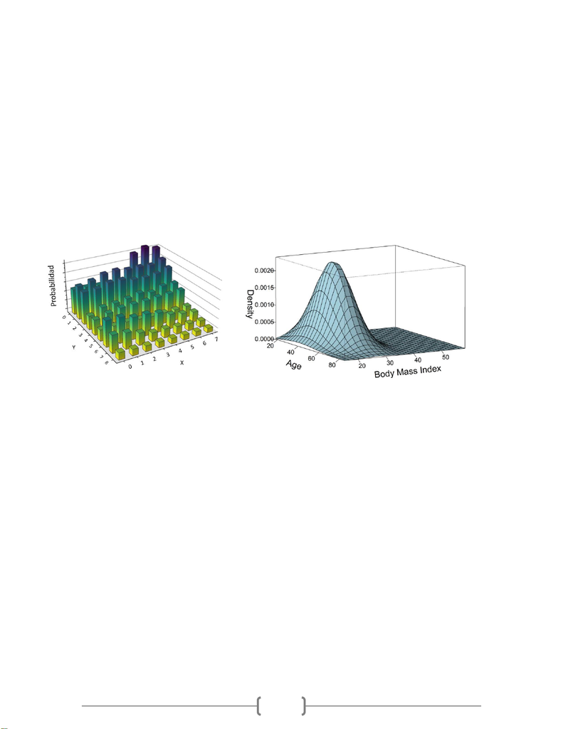

1

Ejercicios sugeridos sobre distribuciones bivariadas

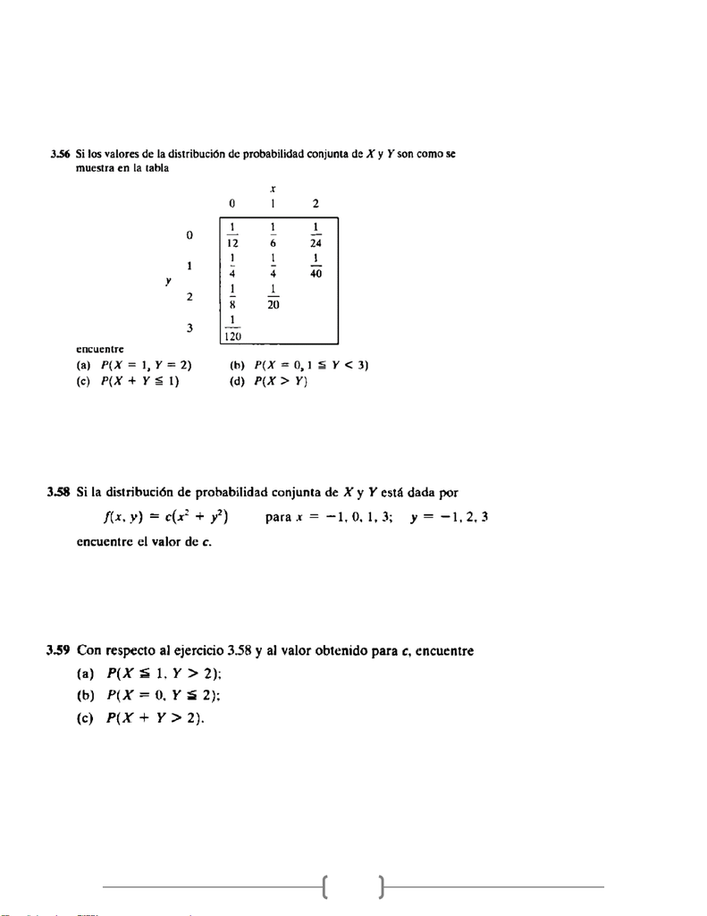

2

Ejercicios sobre distribuciones bivariadas

Ejercicio 3.56 de Freund et al. (2010)

Rtas: a) 1/20, b)3/8, c)1/2, d) 7/30.

Ejercicio 3.58 de Freund et al. (2020)

Rta: c=1/89.

Ejercicio 3.59 de Freund et al. (2020)

Rtas: a) 29/89, b)5/89, c) 55/89.

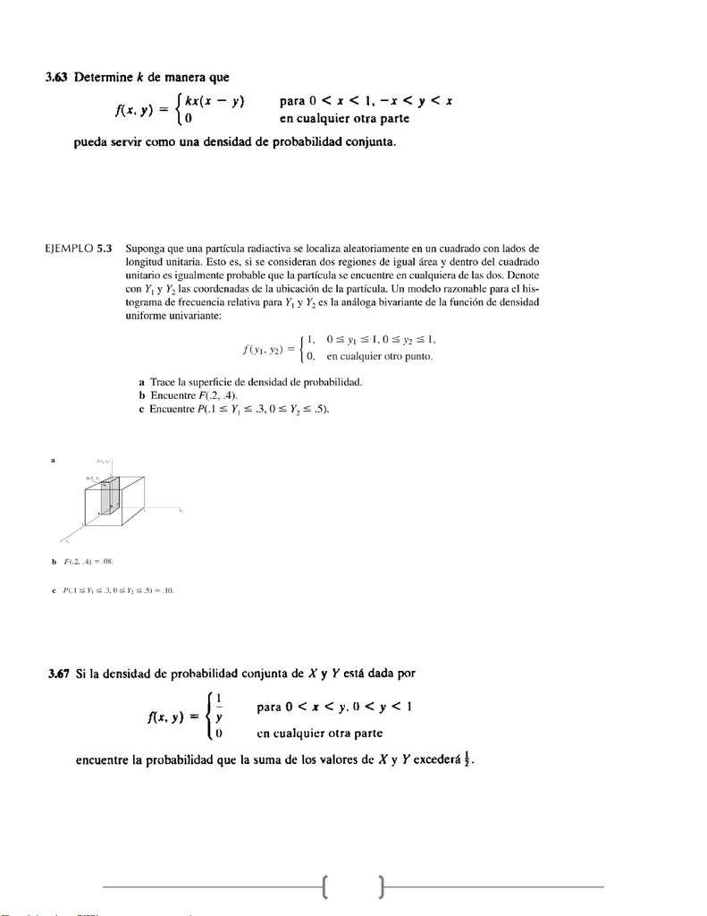

3

Ejercicio 3.63 de Freund et al. (2020)

Rta: k=2.

Ejemplo 5.3 de Wackerly (2010)

Rtas:

Ejercicio 3.67 de Freund et al. (2020)

Rta: 1-0.5 log(2)

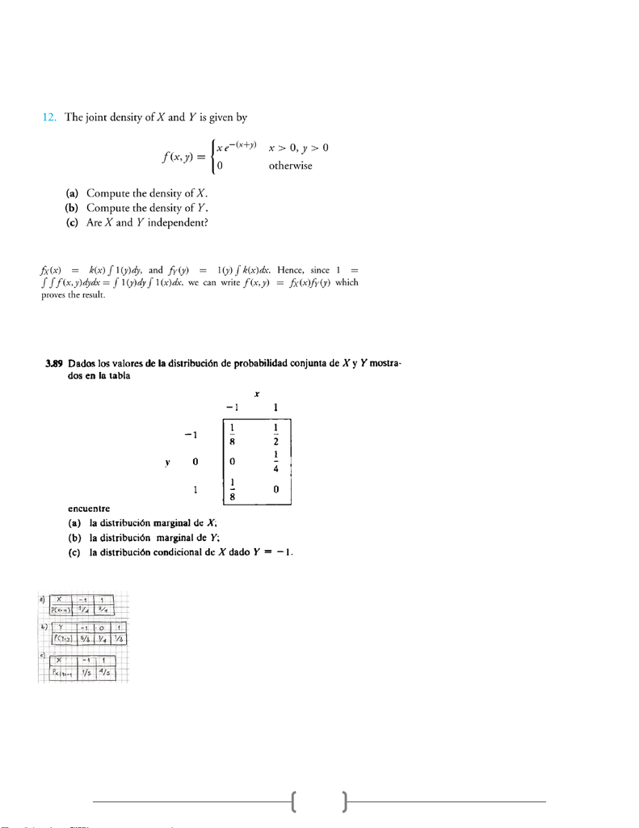

4

Ejercicios sobre distribuciones marginales, condicionales e independencia

Ejercicio 4.12 de Ross (2014)

Rtas:

Ejercicio 3.89 de Freund et a. (2010)

Rtas:

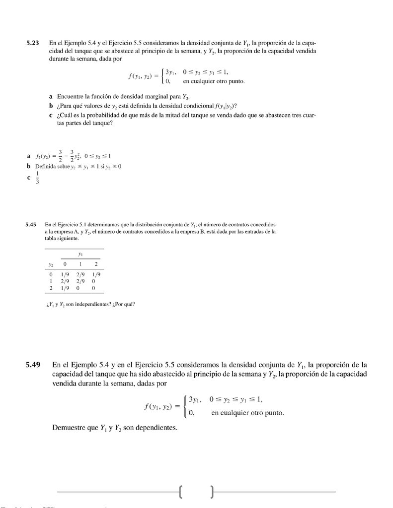

5

Ejercicio 5.23 de Wackerly (2010)

Rtas:

Ejercicio 5.45 de Wackerly (2010)

Rta: no.

Ejercicio 5.49 de Wackerly (2010)

Rta: se debe hacer el procedimiento para mostrar lo que ya se sabe.

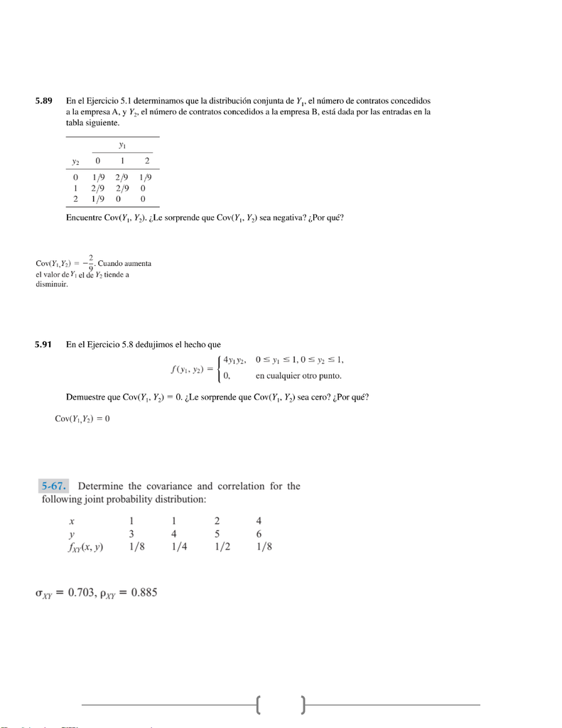

6

Ejercicios sobre covarianza y correlación

Ejercicio 5.89 de Wackerly (2010)

Rta:

Ejercicio 5.91 de Wackerly (2010)

Rta:

Ejercicio 5.67 de Montgomery (2003)

Rtas:

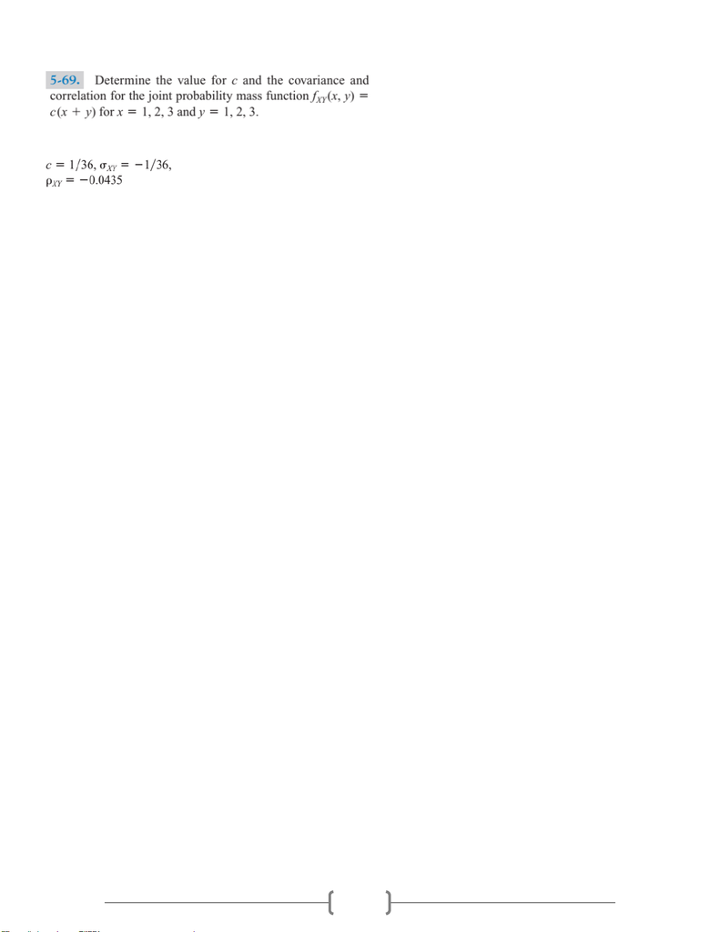

7

Ejercicio 5.69 de Montgomery (2003)

Rtas:

[figure not shown]

8

Hacer los ejemplos y ejercicios del texto guía: